# Comment stocker ses produits chimiques en toute sécurité ? - SECURINORME

## Quelles sont les règles pour le stockage des produits chimiques ?

### Voici quelques règles à respecter pour le stockage des produits chimiques :

- **Limiter l’accès au stock** aux personnes formées et autorisées.
- Tenir à un jour l’**état du stock.**
- Subordonner le stockage d’un produit à l’**existence de sa fiche de données de sécurité réglementaire et de son étiquetage**.
- **Mettre en place un classement rigoureux et connu** : affichage d’un plan, interdiction d’entreposer des emballages volumineux ou lourds en hauteur, pas d’entreposage d’outillage et de matériel dans le local de stockage de produits chimiques.
- Instaurer une **règle de déstockage PEPS « Premier entré, premier sorti »**, ou FIFO en anglais.
- Respecter les **dates de péremption de produits**.
- Mettre en place une **procédure d’élimination** des produits inutiles ou périmés.
- **Interdire l’encombrement** des voies d’accès, des issues et équipements de secours.

### L'armoire de sécurité, équipement industriel indispensable pour les produits dangereux

**L’armoire de sécurité** est un **équipement industriel indispensable** pour toute société ou tout laboratoire qui manipule des produits dangereux. Le but est de stocker ceux-ci dans des lieux appropriés, afin de **préserver la sécurité des personnes** et protéger l’environnement de toute pollution accidentelle. C’est le rôle des [armoires de sécurité](https://www.securinorme.com/517-armoires-de-retention-stockage). Les **armoires anti-feu protègent les produits inflammables** - et donc les personnes et les biens - d**’un risque d’incendie ou d’une source de chaleur** anormalement forte. La protection contre les flammes est assurée par le confinement de l’armoire grâce notamment à la fermeture automatique des portes sur de nombreux modèles, à la présence de joints thermodilatants ou encore à la présence de clapets coupe-feu en entrée et sortie d’aération (norme EN14470-1).

[figure not shown]

>[En lire plus sur les normes et réglementations concernant les armoires de sécurité](https://www.securinorme.com/prevention-au-travail/297-comment-choisir-son-armoire-de-securite-)

>[Voir notre gamme d'armoires anti feu 60 ou 90 min](https://www.securinorme.com/517-armoires-de-retention-stockage)

## Quelle signalisation pour les lieux de stockage des produits chimiques ?

Les lieux de stockage doivent être clairement identifiés. Des **panneaux d’avertissement** doivent figurer à l’entrée ainsi que le **plan de stockage,** indiquant la localisation des différents produits ou encore la capacité maximale. Toute autre information par affichage, comme le récapitulatif de l’étiquetage des produits entreposés et le rappel des incompatibilités éventuelles peuvent être prévus.

Il est aussi possible d’afficher des pictogrammes concernant les précautions à prendre ou le port d’une combinaison.

> [Retrouvez notre sélection de panneaux de signalisation](https://www.securinorme.com/415-signaletique)

## Les incompatibilités de stockage

[figure not shown]

D’autres encore réagissent violemment avec l’eau : ils doivent donc être entreposés de façon à ce que **tout contact avec de l’eau soit impossible**, même lors d’inondation (P223, H260, H261, EUH014, EUH029).

Enfin, les **produits inflammables** doivent être stockés à part dans une enceinte dédiée et constamment ventilée.

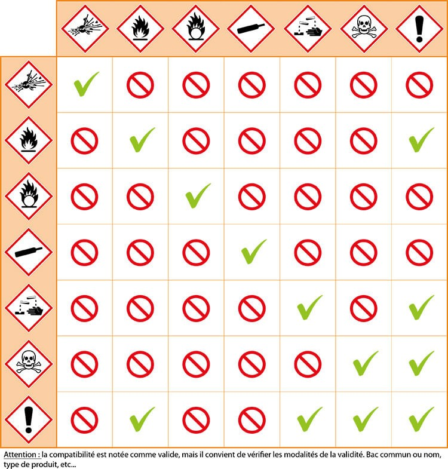

[Retrouvez toutes les informations sur les posters CLP à afficher dans votre établissement.](https://www.securinorme.com/440-signalisation-risques-chimiques-et-biologiques)

## La prévention et la lutte contre l’incendie

Il est fortement conseillé de prévoir un **local isolé du reste du bâtiment** pour le stockage de produits chimiques en quantités importantes afin d’éviter la propagation d’un incendie qui pourrait s’y déclarer. Il doit aussi par conséquent être bâti à l’aide de **matériaux durs et incombustibles** et muni de **systèmes d'évacuation et de lutte contre le feu** appropriés comme des portes coupe-feu, des extincteurs ou des Robinets d’Incendie Armé. L’accès au local doit être facile, permettant une évacuation rapide en cas d’accident. Une localisation en sous-sol est à proscrire.

De même, l’**installation électrique** doit être réduite au minimum indispensable à l’intérieur du local et, selon les produits entreposés, être adaptée à une zone où peuvent apparaître accidentellement des atmosphères explosibles.

## La prévention et la lutte contre les dispersions accidentelles

Des capacités de rétention doivent être prévues par catégorie de produits. Le local de stockage doit lui-même être en rétention générale. Un **produit absorbant** approprié aux produits stockés (neutralisant, incombustible) doit être disponible dans le local de stockage, afin de récupérer fuites et gouttes.

Suivant les résultats de l’évaluation des risques, un **appareil respiratoire isolant** (à entretenir et vérifier périodiquement) sera disposé à l’extérieur du local et à proximité de l’entrée et une douche de sécurité ainsi qu’une fontaine oculaire de secours seront accessibles à proximité immédiate.

## La ventilation et le conditionnement d’air

Une **ventilation mécanique**, résistant à la corrosion et assurant un **renouvellement d’air** de 4 à 6 volumes par heure, doit être prévue. En cas de dispersion accidentelle d’un liquide volatil, ce débit doit pouvoir être porté ponctuellement à 20 volumes par heure à l’aide d’une commande située à l’extérieur du local.

Des mesures doivent aussi être prises pour maintenir la température du local à un niveau approprié : le gel peut altérer un certain nombre de préparations et entraîner des ruptures de conditionnement et une température élevée favorise des surpressions préjudiciables aux emballages et dangereuses lors de leur ouverture.

## Les rayonnages

Les rayonnages doivent être réalisés en **matières résistantes mécaniquement et chimiquement** et doivent être stables pour éviter le basculement. Leur espacement doit être adapté à la circulation des personnes ou d’équipements de manutention. Les produits doivent être faciles d’accès et bien visibles : un éclairage suffisant, **300 lux**, doit être prévu.

[figure not shown]

[figure not shown]

[figure not shown]

[figure not shown]

[figure not shown]

[figure not shown]

[figure not shown]